# Content

- Start: generate ensemble [...]
- Compare different ways to extract uncertainties
  - 1) visual comparison of solutions
  - 2) is there a hidden transformation: This section contains the correlation plots  
    -summary
- Let's just give it a try -- what is the difference?
  - real Dy dataset
  - synthetic dataset
  - summary

# Getting started

```python
%load_ext autoreload
%autoreload 2
%matplotlib inline
```

```python
import matplotlib.pyplot as plt
import numpy as np
import logging
import copy
from pathlib import Path
```

```python
# Load the submodule, so that we are sure we use the same version
import sys
sys.path.insert(0, "ompy")
import ompy as om
```

```python
from matplotlib import rc
rc('font',**{'family':'serif','serif':['Computer Modern Roman']})
rc('text', usetex=True)
rc('axes', labelsize="large")
rc('errorbar', capsize=2.) # Set error bar style
```

```python
om.__full_version__
```

```
'0.9.1.dev0+0713f82'
```

```python
# For reproducability we seed the random generator.
# Note that by default several other classes in ompy, such as all
# classes with multinest calculations have a default seed, too
np.random.seed(1382398)
```

```python
# get smaller files for the online version
plt.rcParams["figure.dpi"] = 70
```

## Loading and example raw spectra

The $^{164}\mathrm{Dy}$ data used below has been gathered from following experiment: Nyhus, H. T. *et al.* (2010). DOI: [10.1103/physrevc.81.024325](https://doi.org/10.1103/PhysRevC.81.024325) and is reanalyzed in Renstrøm, T. *et al.* (2018). DOI: [10.1103/physrevc.98.054310](https://doi.org/10.1103/PhysRevC.98.054310)

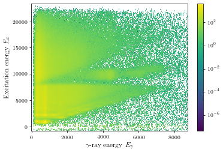

```python
# Import raw matrix into instance of om.Matrix() and plot it
raw = om.example_raw('Dy164')
# To use you own data, uncomment/adapt the line below instead
# raw = om.Matrix(path="/path/to/matrix.ending")

# Plot the entire matrix
raw_org = raw.copy() # workaround due to execution order in jupyter notebook
                     # (calculations are performed before plotting, but we make a cut to raw further down)
raw_org.plot();


# Note: We use the semi-colon `;` at the end of the line to silence the output
# in jupyter notebook. This is not necessary, but otherwise you get something like
# this below printed every time:
#(<matplotlib.collections.QuadMesh at 0x7fafbc422eb8>,
# <matplotlib.axes._subplots.AxesSubplot at 0x7fafc0944a20>,
# <Figure size 640x480 with 2 Axes>)
```

## Matrix manipulation

The core of the Oslo method involves working with two dimensional spectra. Starting with a raw matrix of $E_x$-$E_\gamma$ coincidences, you typically want to unfold the counts along the gamma-energy axis and then apply the first-generation method to obtain the matrix of first-generation, or primary, gamma rays from the decaying nucleus.

The two most important utility classes in the package are `Matrix()` and `Vector()`. They are used to store matrices (2D) or vectors (1D) of numbers, typically spectra of counts, along with energy calibration information.

As these underpin the entire package, they contain many useful functions to make life easier. Loading and saving to several formats, plotting, projections, rebinning and cutting, to mention a few. See the documentation for an exhaustive list.

Their basic structure is:

```python
# mat = ompy.Matrix()
mat = raw
mat.values  # A 2D numpy array
mat.Ex      # Array of mid-bin energy values for axis 0 (i.e. the row axis, or y axis)
mat.Eg      # Array of mid-bin energy values for axis 1 (i.e. the column axis, or x axis)

print("The first gamma-ray energies:\n", mat.Eg[0:10])
```

```
The first gamma-ray energies:
 [  0.     19.364  38.728  58.092  77.456  96.82  116.184 135.548 154.912
 174.276]
```

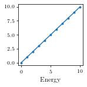

```python
# We can also create a vector, which is useful to store the NLD and gSF.
values = np.arange(11)
E = np.linspace(0, 10, num=11)

fig, ax = plt.subplots(figsize=(2,2), constrained_layout=True)
vec = om.Vector(values=values, E=E)
vec.values  # A 1D numpy array
vec.E       # Array of lower-bin-edge energy values for the single axis
vec.plot(ax=ax);
```

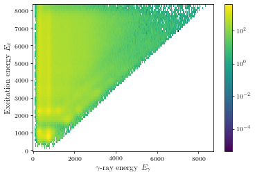

```python
# Cut away counts above the diagonal
# Remember: Think about what you do here. If you cut them away, they will not
# be used in unfolding etc. This may or may not be what you want.
# Note that the raw matrix we read in above has been cut already, so the difference here is not so large.
raw.cut_diagonal(E1=(800, 0), E2=(7500, 7300))
raw.cut('Ex', 0, 8400)
raw.plot();
```

Note that `Matrix`, `Vector` and several other classes contain mutable objects. If you work on them, you might want to create a *deepcopy*. For `Matrix`, `Vector` this can be archived by the convince method `X.copy`, otherwise use `copy.deepcopy`.

```python
# The "right" way if you don't want to change the original matrix
raw_big_cut = raw.copy()
raw_big_cut.cut('Ex', 0, 4000)
print(raw.Ex.max(), raw_big_cut.Ex.max())
```

```
8300.0 3980.0
```

```python
# The "wrong" way if you don't want to change the original matrix
raw_big_cut2 = raw_big_cut
raw_big_cut2.cut('Ex', 0, 2000)
print(raw_big_cut.Ex.max(), raw_big_cut2.Ex.max())
# oups!: suddenly also `raw_big_cut` was cut, not only raw_big_cut2
```

```
1940.0 1940.0
```

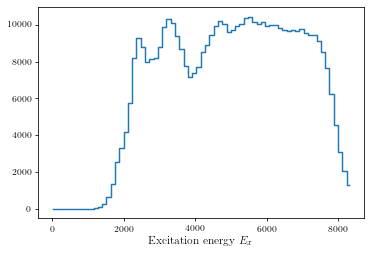

```python
# Plot projections
raw.plot_projection('Ex', Emin=1800, Emax=2600, kind="step");
```

Note that you can IPython's has tools to quickly access information on a function, namely the `?` character to explore documentation, the `??` characters to explore source code, and the `Tab key` (or `double-tab`) for auto-completion. Try it out uncommenting the function below.

```python
## Uncomment these lines to query a function
# ?raw.plot_projection
```

## Unfolding

### Get a response matrix

Eventhough this experiment was performed with CACTUS, we will now give an example *as if* the data was taken with OSCAR. This is beacause it is slightly easier to handle. For CACTUS, the response functions do not include the detector threshold; this has do be taken into account separately.

```
2020-03-31 15:31:20,488 - ompy.response - INFO - Note: Spectra outside of 200.0 and 20000.0 are extrapolation only.
2020-03-31 15:31:27,246 - ompy.response - INFO - Note: Spectra outside of 200.0 and 20000.0 are extrapolation only.
```

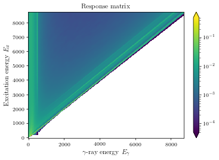

```python
logger = om.introspection.get_logger('response', 'INFO')
# Then do the same using OMpy functionality:
# You may need to adpot this to whereever you response matrices are stored
folderpath = "ompy/OCL_response_functions/oscar2017_scale1.15"

# Energy calibration of resulting response matrix:
Eg = raw.Eg

# Experimental relative FWHM at 1.33 MeV of resulting array
fwhm_abs = 30 # (30/1330 = 2.25% )

# Magne recommends 1/10 of the actual resolution for unfolding purposes
response = om.Response(folderpath)
R_ompy_view, R_tab_view = response.interpolate(Eg, fwhm_abs=fwhm_abs, return_table=True)
R_ompy_unf, R_tab_unf = response.interpolate(Eg, fwhm_abs=fwhm_abs/10, return_table=True)
R_ompy_view.plot(title="Response matrix", vmin=5e-5, vmax=5e-1,
                 scale="log");
```

### Perform the unfolding

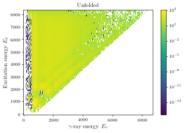

```python
# You can decide to log information and set the logging level (info/debug)
logger = om.introspection.get_logger('unfolder', 'INFO')

# We need to remove negative counts (unphysical) in the raw matrix before unfolding:
raw_positive = raw.copy()
raw_positive.fill_and_remove_negative(window_size=2)

# With compton subtraction and all tweaks
unfolder= om.Unfolder(response=R_ompy_unf)
unfolder.use_compton_subtraction = True # default
unfolder.response_tab = R_tab_unf
# Magne suggests some "tweaks" for a better unfolding performance. Default is 1 for all.
unfolder.FWHM_tweak_multiplier = {"fe": 1., "se": 1.1,
                                     "de": 1.3, "511": 0.9}
unfolded = unfolder(raw_positive)
unfolded.plot();
```

### Generate the first generation matrix

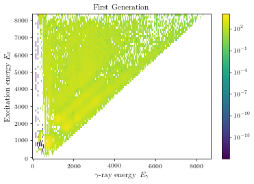

```python
firstgen = om.FirstGeneration()
primary = firstgen(unfolded)
primary.plot();
```

## Propagating statistical uncertainties

In order to propagate the statistical uncertainties from the raw matrix, we use an ensemble based method. We start of my generating en ensemble of *raw-like* matrices. The raw counts are Poisson distributed. If we had counted one another time, we would get slightly different results.

More precisely, the counts of the matrix containing `prompt+bg` events and the background events `bg` are each Poisson distributed, where we have `raw = (prompt+bg) - bg_ratio * bg`. The ratio `bg_ratio` is determined by the ratio of the time gate lengths taken to obtain the `prompt+bg` and `bg` spectra. If a `bg` spectrum is provided to the `Ensemble` class, it will calculate the raw spectrum according to the equation above. Otherwise, the provided `raw` spectrum itself is assumed to be Poisson distributed.

We take the number of counts $k_i$ in bin $i$ of the raw matrix $R$ as an estimate for the Poisson parameter ("the mean") $λ_i$ . Note that it is an unbiased estimator for $λ_i$, since $E(k) = λ$. To generate a member matrix $R_l$ of the MC ensemble, we replace the counts in each bin $i$ by a random draw from the distribution $\operatorname{Poisson}(k_i)$.

The class Ensemble() provides this feature. Its basic usage is:

```python
logger = om.introspection.get_logger('ensemble', 'INFO')

# Tell the `Ensemble` class which raw spectrum, what kind of undolfer and first
# generations method to use.
# Note: This will have the same setting as above. We could for example have
# set the first generations method to use a different "valley_collection", or a
# differnt type of "multiplicity_estimation"
ensemble = om.Ensemble(raw=raw_positive)
ensemble.unfolder = unfolder
ensemble.first_generation_method = firstgen
# Generates N perturbated members; here just 10 to speed it up
# the `regernerate` flag ensures, that we don't load from disk; which might result in expected results
# if we have changed something in the input `raw` matrix.
ensemble.generate(200, regenerate=False)
```

```
2020-03-31 15:31:37,425 - ompy.ensemble - INFO - Start normalization with 3 cpus
2020-03-31 15:31:37,510 - ompy.ensemble - INFO - Generating 0
2020-03-31 15:31:37,547 - ompy.ensemble - INFO - Generating 1
2020-03-31 15:31:37,594 - ompy.ensemble - INFO - Generating 2
2020-03-31 15:31:37,630 - ompy.ensemble - INFO - Generating 3
```

[output not shown]

[output cut: 141 more lines]

[output not shown]

The generated members are saved to disk and can be retrieved. Unfolded members can be retrieved as `ensemble.get_unfolded(i)`, for example. Their standard deviation is `ensemble.std_unfolded` for the unfolded matrices, etc.

## Extract Nuclear level density and gamma strength function

After matrix has been cut, unfolded and firstgen'd, perhaps ensembled, its nuclear level density (nld) and gamma strength function ($\gamma$SF) can be extracted using the `Extractor()` class.

The method relies on the relation \begin{align} P(E_x, E_\gamma) \propto NLD(E_x - E_\gamma) \mathcal{T}(E_\gamma),\label{eq:Oslo_method_eq} \end{align} where $P(E_x, E_\gamma)$ is the first-generation spectrum normalized to unity for each $E_x$ bin.  
Furthermore, if we assume that the $\gamma$ decay at high $E_x$ is dominated by dipole radiation the transmission coefficient $\mathcal{T}$ is related to the dipole $\gamma$-ray strength function $f(E_\gamma)$ by the relation \begin{align} \mathcal{T}(E_\gamma) = 2\pi E_\gamma^3 f(E_\gamma).\label{eq:gammaSF} \end{align}

If you have reasons to assume a different multipole decomposition, you may of course calculate the transmission coefficient $\mathcal{T}$ from the $\gamma$-ray strength function produced here and apply the decomposition you prefer.

For a single matrix, its usage is:  
(well, think about what you want to set in as the std. deviation)

```python
# cutout = primary.trapezoid(Ex_min=4000, Ex_max=8000, Eg_min=1000, inplace=False)
# cutout_std = ensemble.std_firstgen.trapezoid(Ex_min=4000, Ex_max=8000, Eg_min=1000, inplace=False)
# extractor = om.Extractor()
# nld, gsf = extractor.decompose(cutout, std=cutout_std)
```

When extracting NLD and GSF from an ensemble, a trapezoidal cutout must be performed on each ensemble member. This is achieved by `Action()` which allows for delayed function calls on matrices and vectors. This way we don't cut the raw matrix at `Ex_min`, but this will only happen before the extraction.

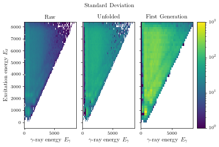

```python
# logger = om.introspection.get_logger('extractor', 'INFO')
trapezoid_cut = om.Action('matrix')
trapezoid_cut.trapezoid(Ex_min=4000, Ex_max=7000, Eg_min=1000, Eg_max=7000+200, inplace=True)
extractor = om.Extractor()
extractor.trapezoid = trapezoid_cut
# Running the lines below directy, would most probably
# result in a error like
# The AssertionError: Ex and Eg must have the same step size
#
# Why? The extraction assumes that Ex and Eg have the same binning. Thus we
# need to rebin the ensemble. This works will work inplace.
# Note: As always, be careful will mid-bin vs lower bin calibration.
# E_rebinned = ensemble.get_firstgen(0).Ex
#
E_rebinned = np.arange(100., 8500, 200)
ensemble.rebin(E_rebinned, member="firstgen")
ensemble.plot();
```

Now we can extract the NLD and $\gamma SF$ for $N$ of the samples of the ensemble.

Note: The old software extended the decomposition beyond the `Ex=Eg` line by a resolution `dE`. This is now optional and we changed the default to not do this any longer, but rather assume that the rebinning above has been performed with a binsize of approx. the FWHM of the bin with the worst resolution (usually `(Ex_max, Eg_max)`).

```python
extractor.extract_from(ensemble, regenerate=True)
```

The resulting `nld` and `gsf` are saved to disk and exposed as `extractor.nld` and `extractor.gsf`

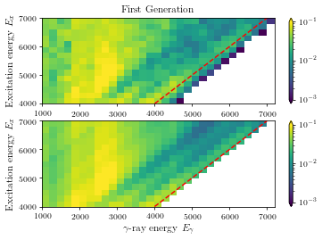

```python
mat = ensemble.get_firstgen(0).copy()
std = ensemble.std_firstgen.copy()
trapezoid_cut.act_on(mat)
trapezoid_cut.act_on(std)
_, _, product = extractor.decompose(mat, std, product=True)
fig, ax = plt.subplots(2,1)
om.normalize_rows(mat.values)
mat.plot(ax=ax[0], scale="log", vmin=1e-3, vmax=1e-1)
product.plot(ax=ax[1], scale="log", vmin=1e-3, vmax=1e-1)

x = np.linspace(*ax[0].get_ylim())
ax[0].plot(x, x, "r--", label="E_x = E_g")
ax[1].plot(x, x, "r--", label="E_x = E_g")
```

### Plotting the results before normalization

```
(<Figure size 420x280 with 2 Axes>,
 array([<matplotlib.axes._subplots.AxesSubplot object at 0x7f85772dc128>,
       dtype=object))
```

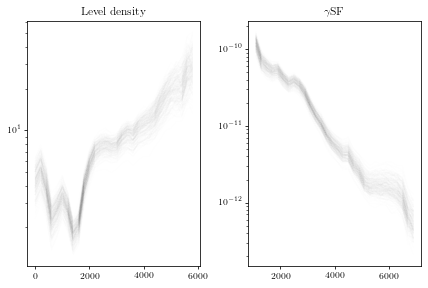

```python
extractor.plot(plot_mean=False)
```

Or maybe you are more used to displaying the results with std. deviations?

**Note**: This may be erroneous, as the nld and gsf are not normalized yet!  
Thus, in principal, we might evaluate std. devs. of the *same solution* with different  
transformations. Before we normalize, we don't know. And they have the same $\chi^2$.  
That was the reason for the *trouble* with normalization.

```
(<Figure size 420x280 with 2 Axes>,
 array([<matplotlib.axes._subplots.AxesSubplot object at 0x7f857569b4a8>,
       dtype=object))
```

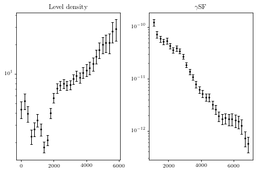

```python
extractor.plot(plot_mean=True)
```

## Compare different ways to extract uncertainties

### 1) visual comparison of solutions

- extract with **randomized initial**, starting from BSFG-like p0 (like in article as of 31 Mar 2020)

```
(<Figure size 420x280 with 2 Axes>,
 array([<matplotlib.axes._subplots.AxesSubplot object at 0x7f8575396198>,
       dtype=object))
```

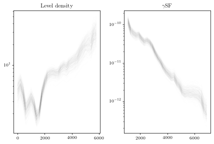

```python
extractor.plot(plot_mean=False)
```

- extract **without randomized initial**, starting from BSFG-like p0

```
(<Figure size 420x280 with 2 Axes>,
 array([<matplotlib.axes._subplots.AxesSubplot object at 0x7f857729f828>,
       dtype=object))
```

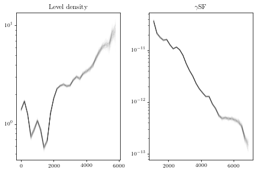

```python
# logger = om.introspection.get_logger('extractor', 'INFO')
extractor.path=Path("test_bsfg/")
extractor.path.mkdir(exist_ok=True)
extractor.x0 = "BSFG-like"
extractor.randomize_initial_values = False
extractor.extract_from(ensemble, regenerate=True)
extractor.plot(plot_mean=False)
```

- extract **without randomized initial**, starting from CT-like p0

```
(<Figure size 420x280 with 2 Axes>,
 array([<matplotlib.axes._subplots.AxesSubplot object at 0x7f85742eb780>,
       dtype=object))
```

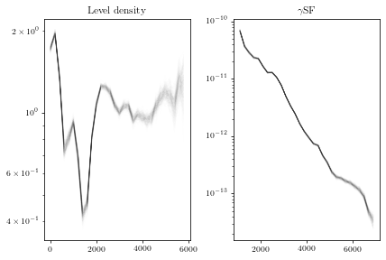

```python
# logger = om.introspection.get_logger('extractor', 'INFO')
extractor.path=Path("test_ct/")
extractor.path.mkdir(exist_ok=True)
extractor.x0 = "CT-like"
extractor.randomize_initial_values = False
extractor.extract_from(ensemble, regenerate=True)
extractor.plot(plot_mean=False)
```

Summary:

- Without the randomization of the initials, the solutions for each ensemble member seem to overlap rather well.
- We have to analyze whether small transformations would be allowed and if so, to what extend they may influence the results
- When the trail functions are randomized, the solutions have obviously different transformations
  - at least in this case, it would be necessary to normalize each ensemble member separately
  - why should one randomize trial functions -> potentially better exploration of parameter space
- We can also get an idea (not a proof!) of the sensitivity towards the trial function comparing the `BSFG-like` and the `CT-like` extractor

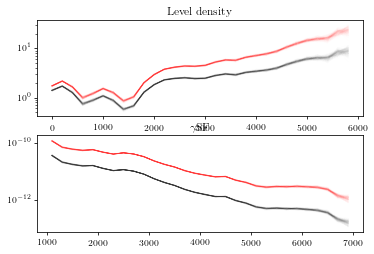

```python
fig, ax = plt.subplots(2,1)

# load BSFG-like results
extractor.path = Path("test_bsfg/")
extractor.extract_from(ensemble, regenerate=False)
extractor.plot(ax=ax, plot_mean=False, color="k");

# load the results with the CT-like initial, transform and plot
# Note that the transformation is choosen manually, to resemble the BSFG-like results
#      and only see potential "statistical" deviations
extractor.path = Path("test_ct/")
extractor.extract_from(ensemble, regenerate=False)

alpha = 0.0005
for nld, gsf in zip(extractor.nld, extractor.gsf):
    nld.transform(alpha=alpha)
    gsf.transform(alpha=alpha)

extractor.plot(ax=ax, plot_mean=False, color="r");
```

It seems like we get quite similar results here, even though we used a different initial guess. That is good and *hints* towards a good exploration of the parameter space -- so this should maybe not be the largest concern. Nevertheless different samplers should/could be tested; the best sampler could be chosen based on the best $\chi^2$

PS: I've check another sampler now, too. The differential evolution sampler from scipy, again without randomization of the initial variables (but this doesn't *help*, as differential evolution does not have initial values, but boundaries. So there is not initial value from which we can wander off.

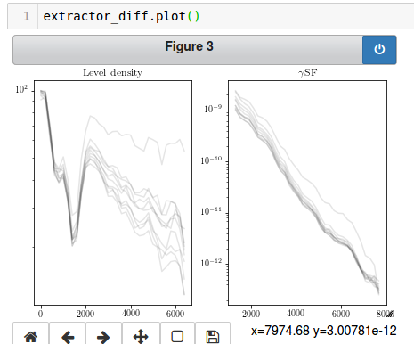

### 2) is there a small "hidden" transformation?

We can try to analyze whether the solutions from the sampler could have a small "hidden" transformation inbuilt. In principle, this is possible, as we sample from a degenerate $\chi^2$ -- so the minimizer could pick up solutions that would overall be the same but have (slightly) different $\alpha$'s (or $A$, $B$). Many minimizers will probably not try $\rho_0$ and $10*\rho_0$, so we might not get largely different transformation parameters. It would be interesting however to see the behavior of s.th. like differential evolution, MultiNest or similar samplers that sample more freely in the parameter space.

In the following we analyze the dependence of the $\gamma$SF on the number of counts in the bin that constrains the $\gamma$SF. For the comparison, we select the the last bin in the $\gamma$SF as it only depends on one bin in the $P(E_x, E_\gamma)$ matrix. In addition, we fix the corresponding NLD bin, such that any variations in the number of counts should directly propagate to the $\gamma$SF (instead of being shared between the effect on the NLD and $\gamma$SF).

**We start by defining a minimizer where the NLD at Ex=0 is fixed**  
The only change to the original `decompose` method is in the `\chi**2`, where we set a large penalty for deviations from a values of 1.17 (= fixing nld in that point to 1.17). The bin to fix is determined via the new attribute `self.fix_bin`

```python
from scipy.optimize import minimize
from ompy.decomposition import chisquare_diagonal, nld_T_product

class ExtractorFix(extractor.__class__):
    def decompose(self, matrix,
                  std = None,
                  x0 = None,
                  product = False):
        """ Decomposes a matrix into nld and γSF

        Algorithm:
            Creates the energy range for nld based on the diagonal
            energy resolution. Tries to minimize the product::

                firstgen = nld·gsf

            using (weighted) chi square as error function.

            If first nld / last gsf elements cannot be constrained, as there
            are no entries for them in the matrix, they will be set to `np.nan`

        Args:
            matrix: The matrix to decompose. Should already
                be cut into appropiate size
            std: The standard deviation for the matrix. Must
                be the same size as the matrix. If no std is provided,
                square error will be used instead of chi square.
            x0: The initial guess for nld and gsf. If `np.ndarray`, ordered as
                (T0, nld0). Otherwise, if `str`, used as the method, see
                `guess_initial_values` (where also defaults are given).
            product: Whether to return the first generation matrix
               resulting from the product of nld and gsf.

        Returns:
            The nuclear level density and the gamma strength function
            as Vectors.
            Optionally returns `nld*γSF` if `product` is `True`

        """
        if np.any(matrix.values < 0):
            raise ValueError("input matrix has to have positive entries only.")
        if std is not None:
            std = std.copy()
            if np.any(std.values < 0):
                raise ValueError("std has to have positive entries only.")
            assert matrix.shape == std.shape, \
                f"matrix.shape: {matrix.shape} != std.shape : {std.shape}"
            std.values = std.values.copy(order='C')
            matrix.values, std.values = om.extractor.normalize(matrix, std)
            matrix.Ex = matrix.Ex.copy(order='C')
            matrix.Eg = matrix.Eg.copy(order='C')
        else:
            matrix.values, _ = normalize(matrix)

        # Eg and Ex *must* have the same step size for the
        # decomposition to make sense.
        dEx = matrix.Ex[1] - matrix.Ex[0]
        dEg = matrix.Eg[1] - matrix.Eg[0]
        assert dEx == dEg, \
            "Ex and Eg must have the same bin width. Currently they have"\
            f"dEx: {dEx:.1f} and dEg: {dEg:.1f}. You have to rebin.\n"\
            "The `ensemble` class has a `rebin` method."
        bin_width = dEx

        # create nld energy array
        Emin = matrix.Ex.min()-matrix.Eg.max()
        Emax = matrix.Ex.max()-matrix.Eg.min()
        E_nld = np.linspace(Emin, Emax, int(np.ceil((Emax-Emin)/bin_width))+1)

        if self.extend_fit_by_resolution:
            resolution = self.diagonal_resolution(matrix)
        else:
            resolution = np.zeros_like(matrix.Ex)

        x0 = self.x0 if x0 is None else x0
        if x0 is None or isinstance(x0, str):  # default initials or method
            x0 = self.guess_initial_values(E_nld, matrix, x0)
        assert len(x0) == E_nld.size + matrix.Eg.size
        if self.randomize_initial_values:
            x0 = np.random.uniform(x0/5, x0*5)  # arb. choice for bounds

        def errfun(x: np.ndarray) -> float:
            # Add a non-negative constraint
            if np.any(x < 0):
                return 1e20

            T = x[:matrix.Eg.size]
            nld = x[matrix.Eg.size:]
            fit = nld_T_product(nld, T, resolution,
                                E_nld, matrix.Eg, matrix.Ex)

            # FIX NLD through chi2:
            nld_diff = (nld[self.fix_bin] - 1.17)**2

            if std is None:
                return np.sum((matrix.values - fit)**2)
            else:
                chi = chisquare_diagonal(matrix.values, fit, std.values,
                                         resolution, matrix.Eg, matrix.Ex)
                return chi + 10000*nld_diff

        #         LOG.info("Minimizing")
        #         LOG.write = lambda msg: LOG.info(msg) if msg != '\n' else None
        #         with redirect_stdout(LOG):
        bounds = np.column_stack([x0/10, x0*10])
        bounds[:, 0] /= 10
        bounds[:, 1] *= 10
        res = minimize(errfun, x0=x0, method=self.method,
                           options=self.options)
        T = res.x[:matrix.Eg.size]
        nld = res.x[matrix.Eg.size:]

        # Set elements that couldn't be constrained (no entries) to np.na
        nld_counts0, T_counts0 = self.constraining_counts(matrix, resolution)
        T[T_counts0 == 0] = np.nan
        nld[nld_counts0 == 0] = np.nan

        # Convert transmission coefficient to the more useful
        # gamma strength function
        gsf = T/(2*np.pi*matrix.Eg**3)

        if product:
            nld_0 = np.where(np.isnan(nld), np.zeros_like(nld), nld)
            T_0 = np.where(np.isnan(T), np.zeros_like(T), T)
            values = nld_T_product(nld_0, T_0, resolution,
                                   E_nld, matrix.Eg, matrix.Ex)
            mat = om.Matrix(values=values, Ex=matrix.Ex, Eg=matrix.Eg)
            return om.Vector(nld, E_nld), om.Vector(gsf, matrix.Eg), mat

        else:
            return om.Vector(nld, E_nld), om.Vector(gsf, matrix.Eg)
```

```python
# find out which bin we need to fix (which bin corresponds to E=0)
fix_bin = extractor.nld[0].index(0)

extractor_fix = copy.deepcopy(extractor)
extractor_fix.__class__ = ExtractorFix().__class__

extractor_fix.path=Path("test_ct_fix/")
extractor_fix.path.mkdir(exist_ok=True)
extractor_fix.x0 = "CT-like"

extractor_fix.fix_bin = fix_bin
extractor_fix.extract_from(ensemble, regenerate=True)
```